# Ejercicio: TCL

Leo Mansini 318/19

Clase 17 - 11 de junio

1. Calcular $E(\hat p_{n})$ y $V(\hat p_{n})$

$\hat p_{n}$ = $\frac{1}{n}\sum_{i = 1}^{n}X_{i}$ siendo $X_{i}$ un experimento de bernoulli de probababilidad:

$P(A) = 30/36 = 5/6 = 0.833$

$P(B) = 15/36 = 0.4167$

$P(C) = 1/6 = 0.167$

$E(\hat p_{n})$ es una esperanza de una suma de variables aleatorias, por lo que es igual a la suma de las esperanzas de esas variables. $X_{i}$ son iid para todo $i$ entre $1$ y $n$, entonces todas sus esperanzas son iguales:

$$E(\hat p_{n}) = E\left(\frac{1}{n}\sum_{i = 1}^{n}X_{i}\right) = \frac{1}{n}\sum_{i=1}^{n}E(X_{i}) = \frac{1}{n} n E(X_{1}) =E(X_{1})$$

Y la esperanza de un experimento de bernoulli de probabilidad $p$ es igual a esa probabilidad.

Para $P(A)$ $E(\hat p_{n}) = 5/6 = 0.833$

Para $P(B)$ $E(\hat p_{n}) = 15/36 = 0.4167$

Para $P(C)$ $E(\hat p_{n}) = 1/6 = 0.167$

Analogamente busco la varianza.

$$V(\hat p_{n}) = V\left(\frac{1}{n}\sum_{i = 1}^{n}X_{i}\right) = \frac{1}{n^2}\sum_{i=1}^{n}V(X_{i}) = \frac{1}{n^2} n V(X_{1}) = \frac{V(X_{1})}{n}$$
Y la varianza de $X_{1}$ es $p(1-p)$

Para $P(A)$ $V(\hat p_{n}) = 5/36 = 0.139$

Para $P(C)$ $V(\hat p_{n}) = 5/36 = 0.139$

Para estimar la esperanza, puedo hacer un promedio de las mediciones, es decir:

$$E(\tilde p_{n}) = \frac {\sum \hat p_{n}}{\text{#mediciones de }\hat p_{n}}$$

Así,

Para pa.txt $E(\tilde p_{n}) =$

```
## [1] 0.8348163
```

Para pb.txt $E(\tilde p_{n}) =$

```
## [1] 0.419559
```

Para pc.txt $E(\tilde p_{n}) =$

```
## [1] 0.165342
```

Las tres estimaciones son buenas, las tres distan en menos de $0.01$ del valor real.

3. Hago histogramas con las mediciones en pa.txt, pb.txt, pc.txt.

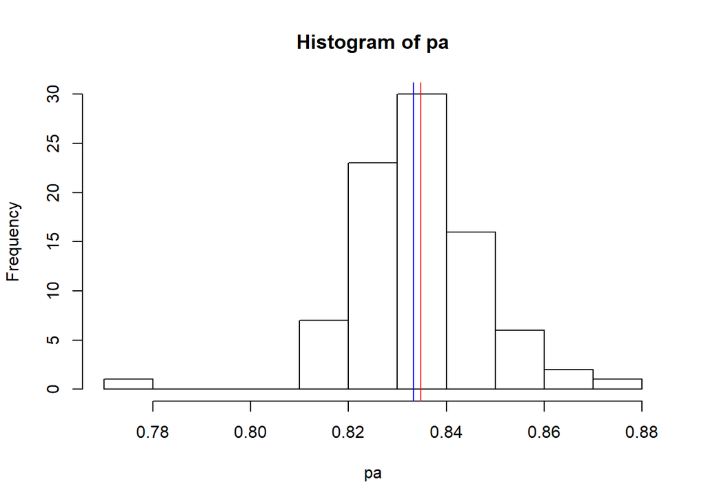

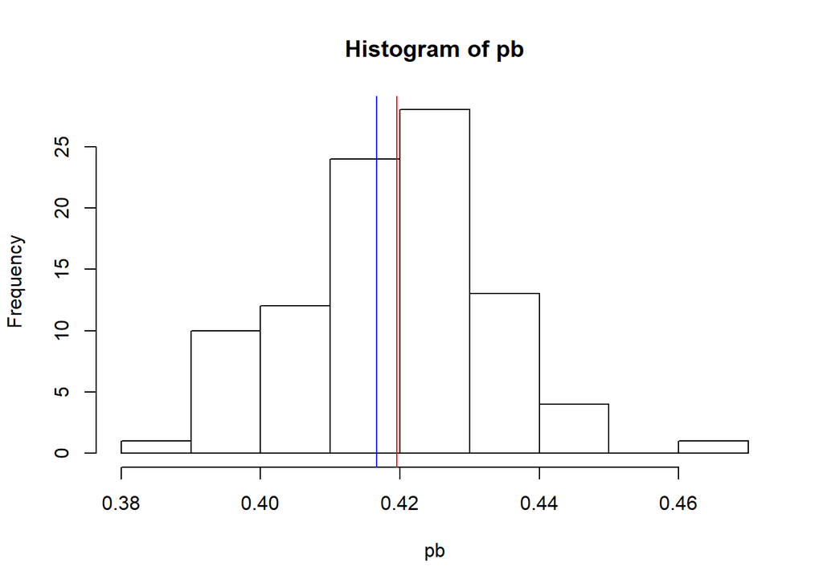

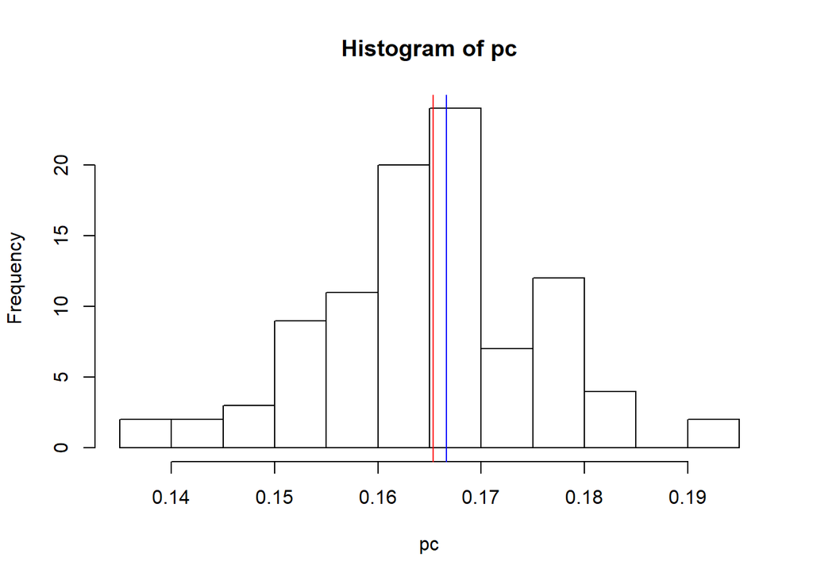

Se ve que el grafico tiene máximo cerca a la esperanza, estan marcadas las esperanzas reales en azul y las estimadas en rojo.